```python
#imports
import seaborn as sns
import matplotlib.pyplot as plt
import sqlite3
import pandas as pd
```

# `Part 1`

Using SQL compute a relation containing the total payroll and winning percentage (number of wins / number of games * 100) for each team (that is, for each teamID and yearID combination). You should include other columns that will help when performing EDA later on (e.g., franchise ids, number of wins, number of games).

Include the SQL code you used to create this relation in your writeup. Describe how you dealt with any missing data in these two relations. Specifically, indicate if there is missing data in either table, and how the type of join you used determines how you dealt with this missing data. One note, for SQL you have to be mindful of integer vs. float division.

I mentioned in the lectures that some folks find Pandas simpler to use than SQL, and that's true. However, there are cases where SQL is unavoidable. If the data is already stored in a database, you'd need to know at least enough SQL to get the data out.

```python
sqlite_file = 'lahman2014.sqlite'
conn = sqlite3.connect(sqlite_file)
salary_query = """SELECT yearID, sum(salary) as
total_payroll FROM Salaries WHERE lgID == 'AL'
 GROUP BY yearID"""

query = """SELECT S.yearID AS year,
          T.franchID AS franchise,
          S.teamID AS team,
          CAST(T.W AS float)/CAST(T.G AS float)*100 AS win_percentage,
          T.G AS games,
          sum(S.salary) AS total_salaries

          FROM Salaries S INNER JOIN Teams T ON
          (S.yearID = T.yearID AND S.teamID = T.teamID)
          GROUP BY S.yearID, S.teamID"""

team_salaries = pd.read_sql(query, conn)
team_salaries.head()
```

|  | year | franchise | team | win_percentage | games | total_salaries |
| --- | --- | --- | --- | --- | --- | --- |
| 0 | 1985 | ATL | ATL | 40.740741 | 162 | 14807000.0 |
| 1 | 1985 | BAL | BAL | 51.552795 | 161 | 11560712.0 |
| 2 | 1985 | BOS | BOS | 49.693252 | 163 | 10897560.0 |
| 3 | 1985 | ANA | CAL | 55.555556 | 162 | 14427894.0 |
| 4 | 1985 | CHW | CHA | 52.147239 | 163 | 9846178.0 |

**Because I used inner join, it would already not display any data that doesn't match with the parameters I've given (i.e. if in there is no salary data from ATL in 1980 then it wouldn't merge)**

# `Part 2: Exploratory Data Analysis`

```python
#Filter then reformat the dataframe so that each column is a team and each row
# indicates some year with the values being the total salary.

new_df = team_salaries.filter(['year','team', 'total_salaries'], axis=1)
new_df = new_df[new_df.year >= 1990] #drop rows <1990
#reformatting dataframe for plotting
newer_df = new_df.pivot(index='year', columns='team', values='total_salaries')
newer_df.head()
```

| team year | ANA | ARI | ATL | BAL | BOS | CAL | CHA | CHN | CIN | CLE | ... | PHI | PIT | SDN | SEA | SFN | SLN | TBA | TEX | TOR | WAS |
| --- | --- | --- | --- | --- | --- | --- | --- | --- | --- | --- | --- | --- | --- | --- | --- | --- | --- | --- | --- | --- | --- |
| 1990 | NaN | NaN | 14555501.0 | 9680084.0 | 20558333.0 | 21720000.0 | 9491500.0 | 13624000.0 | 14370000.0 | 14487000.0 | ... | 13173667.0 | 15556000.0 | 17588334.0 | 12553667.0 | 19335333.0 | 20523334.0 | NaN | 14874372.0 | 17756834.0 | NaN |
| 1991 | NaN | NaN | 18403500.0 | 17519000.0 | 35167500.0 | 33060001.0 | 16919667.0 | 23175667.0 | 26305333.0 | 17635000.0 | ... | 22487332.0 | 23634667.0 | 22150001.0 | 15691833.0 | 30967666.0 | 21860001.0 | NaN | 18224500.0 | 19902417.0 | NaN |
| 1992 | NaN | NaN | 34625333.0 | 23780667.0 | 43610584.0 | 34749334.0 | 30160833.0 | 29829686.0 | 35931499.0 | 9373044.0 | ... | 24383834.0 | 33944167.0 | 26854167.0 | 23179833.0 | 33163168.0 | 27583836.0 | NaN | 30128167.0 | 44788666.0 | NaN |
| 1993 | NaN | NaN | 41641417.0 | 29096500.0 | 37120583.0 | 28588334.0 | 39696166.0 | 39386666.0 | 44879666.0 | 18561000.0 | ... | 28538334.0 | 24822467.0 | 25511333.0 | 32696333.0 | 35050000.0 | 23367334.0 | NaN | 36376959.0 | 47279166.0 | NaN |
| 1994 | NaN | NaN | 49383513.0 | 38849769.0 | 37859084.0 | 25156218.0 | 39183836.0 | 36287333.0 | 40961833.0 | 30490500.0 | ... | 31599000.0 | 24217250.0 | 14916333.0 | 29228500.0 | 42638666.0 | 29275601.0 | NaN | 32973597.0 | 43433668.0 | NaN |

5 rows × 35 columns

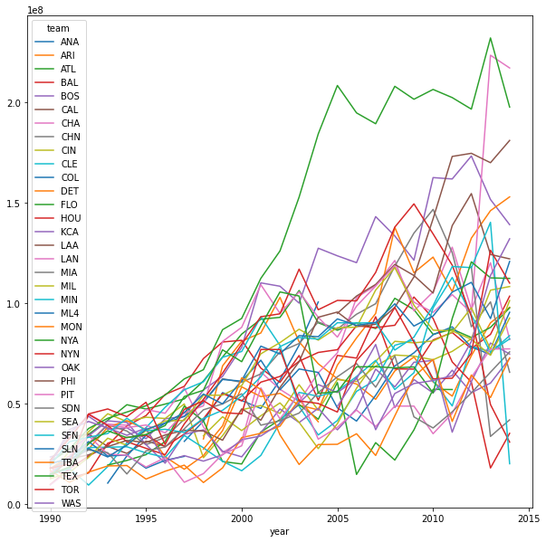

```python
newer_df.plot(figsize=(10,10))
```

**Question 1 (9 pts) What statements can you make about the distribution of payrolls conditioned on time based on these plots? Remember you can make statements in terms of central tendency, spread, etc.**

> 1. Based on the distributions, it appears that the average salary among all of the teams have increased over the years.
> 2. It also appears that in the earlier years, the salaries across different teams have a lot less variation and have also since increased

**Problem 3 (8 pts) Write code to produce plots that specifically show at least one of the statements you made in Question 1. For example, if you make a statement that there is a trend for payrolls to decrease over time, make a plot of a statistic for central tendency (e.g., mean payroll) vs. time to show that specficially.**

> I will use the second statement from my answer in problem 2. I will find the standard deviation from each year and see what happens over time.

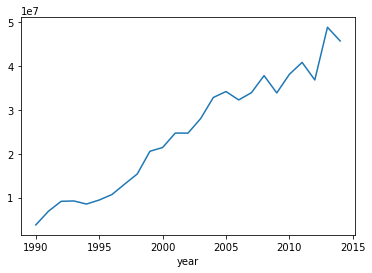

```python
df = newer_df.std(axis=1) #finds stdev of each row
df.plot()
```

Because standard deviation measures how far apart the numbers are, it is a good indicator of the variacne between the different total salaries among the teams. I found the standard deviation at each row of the dataframe and it appears that there is a general upward tren d indicating that there is a lot of variance within the data relative to the average, and that variance is increasing overall

**Problem 4 (8 pts)** **Write code to discretize year into five time periods (you can use pandas.cut to accomplish this) and then make a scatterplot showing mean winning percentage (y-axis) vs. mean payroll (x-axis) for each of the five time periods. You could add a regression line (using, e.g., NumPy's polyfit) in each scatter plot to ease interpretation.**

```python
#another df
yrs = ['1990 to 1994', '1995 to 1999', '2000 to 2004','2005 to 2009', '2010 to 2014']
sals = team_salaries[team_salaries.year >= 1990]
#creating a bin separating out the years
sals['time_pd'] = pd.cut(x=sals['year'], bins=[1989, 1994, 1999, 2004, 2009, 2014],
                       labels=yrs)
```

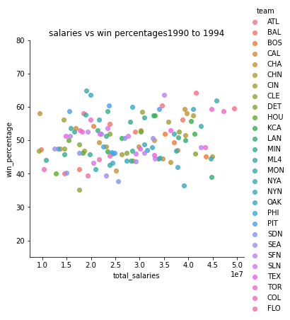

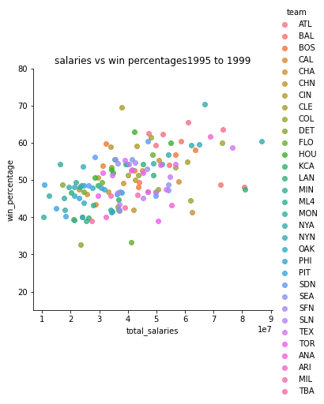

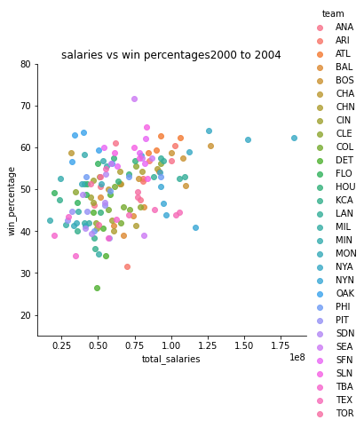

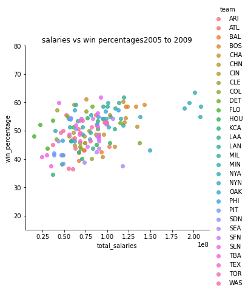

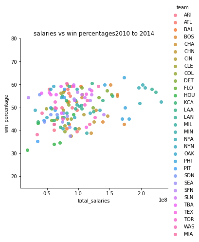

```python
#for each of the available bins, plot
for i in yrs:
  sns.lmplot(x='total_salaries',y='win_percentage',
             data=sals[sals.time_pd == i], hue='team',
             fit_reg=False).set(title="salaries vs win percentages" + i)
  plt.ylim((15, 80))
```

```python
sals.win_percentage[sals.team=='OAK']
```

```
147    63.580247
173    51.851852
199    59.259259
227    41.975309
255    44.736842
283    46.527778
311    48.148148
339    40.123457
368    45.679012
398    53.703704
428    56.521739
458    62.962963
488    63.580247
518    59.259259
548    56.172840
577    54.320988
607    57.407407
637    46.913580
667    46.583851
697    46.296296
727    50.000000
757    45.679012
787    58.024691
817    59.259259
847    54.320988
Name: win_percentage, dtype: float64
```

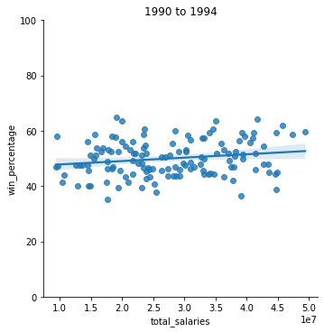

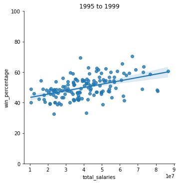

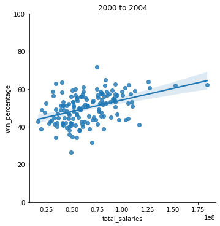

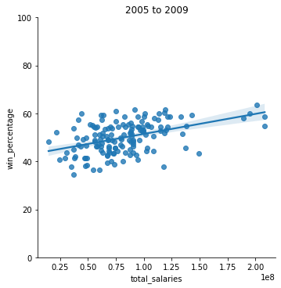

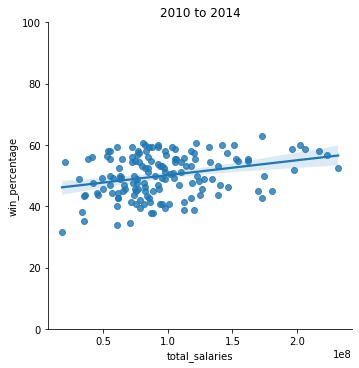

```python
#with regression lines (cannot separate via color otherwise the graphs would be
#too messy to get any meaningful observations in)
#for each of the available bins, plot
for i in yrs:
  sns.lmplot(x='total_salaries',
             y='win_percentage',
             data=sals[sals.time_pd == i]).set(title=i)
  plt.ylim((0, 100))
```

**Question 2 (9 pts) What can you say about team payrolls across these periods? Are there any teams that standout as being particularly good at paying for wins across these time periods? What can you say about the Oakland A's spending efficiency across these time periods (labeling points in the scatterplot can help interpretation)**

# `Part 3: Data Transformations`

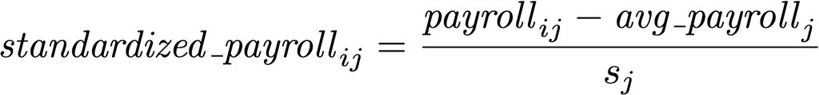

We take the newer_df dataframe (which has the payrolls already separated by team) and take the mean and standard deviations for each, then join the columns based on the team col

```python
means = newer_df.mean().to_frame()
stdevs = newer_df.std().to_frame()
sals = sals.join(stdevs, on='team')
sals = sals.join(means, on='team', how='left', lsuffix='_stdev_total', rsuffix='_avg_total')
```

```python
#quick sanity check, making sure everything lines up
print(sals[sals.team == "ATL"]['0_stdev_total'].head())
print(sals[sals.team == "NYA"]['0_stdev_total'].head())
```

```
130    2.647294e+07
156    2.647294e+07
182    2.647294e+07
208    2.647294e+07
236    2.647294e+07
Name: 0_stdev_total, dtype: float64
145    7.332348e+07
171    7.332348e+07
197    7.332348e+07
225    7.332348e+07
253    7.332348e+07
Name: 0_stdev_total, dtype: float64
```

```python
print(sals[sals.team == "ATL"]['0_avg_total'].head())
print(sals[sals.team == "NYA"]['0_avg_total'].head())
```

```
130    72426077.2
156    72426077.2
182    72426077.2
208    72426077.2
236    72426077.2
Name: 0_avg_total, dtype: float64
145    1.278693e+08
171    1.278693e+08
197    1.278693e+08
225    1.278693e+08
253    1.278693e+08
Name: 0_avg_total, dtype: float64
```

```python
sals['std_payroll'] = (sals['total_salaries']-sals['0_avg_total'])/sals['0_stdev_total']
sals.head()
```

|  | year | franchise | team | win_percentage | games | total_salaries | time_pd | 0_stdev_total | 0_avg_total | std_payroll |
| --- | --- | --- | --- | --- | --- | --- | --- | --- | --- | --- |
| 130 | 1990 | ATL | ATL | 40.123457 | 162 | 14555501.0 | 1990 to 1994 | 2.647294e+07 | 7.242608e+07 | -2.186027 |
| 131 | 1990 | BAL | BAL | 47.204969 | 161 | 9680084.0 | 1990 to 1994 | 2.410658e+07 | 6.279722e+07 | -2.203429 |
| 132 | 1990 | BOS | BOS | 54.320988 | 162 | 20558333.0 | 1990 to 1994 | 4.919682e+07 | 9.463517e+07 | -1.505724 |
| 133 | 1990 | ANA | CAL | 49.382716 | 162 | 21720000.0 | 1990 to 1994 | 4.518190e+06 | 2.903358e+07 | -1.618697 |
| 134 | 1990 | CHW | CHA | 58.024691 | 162 | 9491500.0 | 1990 to 1994 | 3.523446e+07 | 6.621212e+07 | -1.609805 |

Problem 6 (8 pts) Repeat the same plots as Problem 4, but use this new standardized payroll variable.

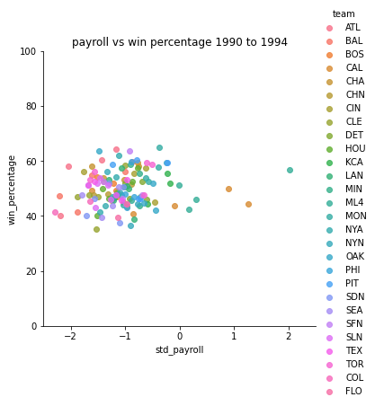

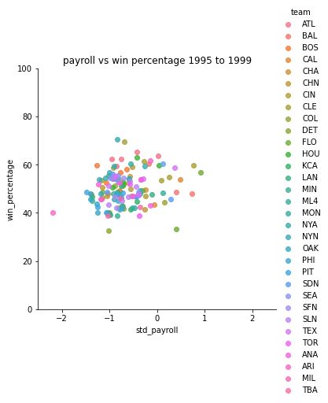

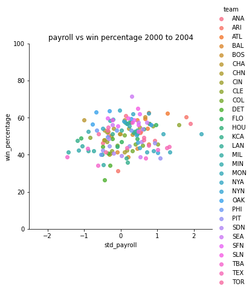

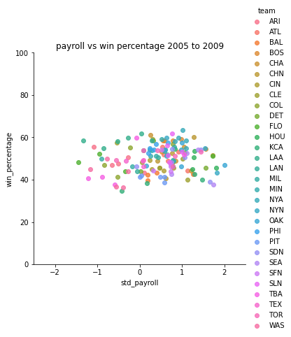

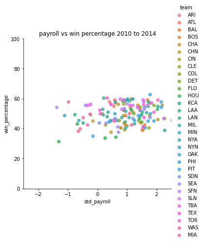

```python
for i in yrs:
  sns.lmplot(x='std_payroll',y='win_percentage',
             data=sals[sals.time_pd == i], hue='team',
             fit_reg=False).set(title="payroll vs win percentage "+ i)
  plt.xlim(-2.5,2.5)
  plt.ylim((0, 100))
```

**Question 3 (9 pts) Discuss how the plots from Problem 4 and Problem 6 reflect the transformation you did on the payroll variable.**

> The data appears to cluster a lot more, and with the transformation in effect it demonstrates how these graphs shows the impacts of salary on the win percentage. We take into account the amount of money that the other teams spend, and due to including the standard deviation into the transformation, the outliers on those that are higher spenders/winners are a lot more apparent than in the first dataset

Problem 7 (8 pts) Make a single scatter plot of winning percentage (y-axis) vs. standardized payroll (x-axis). Add a regression line to highlight the relationship.

```
(0.0, 100.0)
```

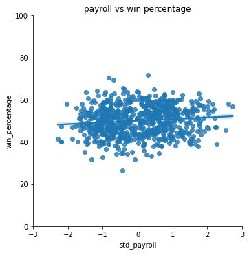

```python
sns.lmplot(x='std_payroll',y='win_percentage',
             data=sals, fit_reg=True).set(title="payroll vs win percentage")
plt.xlim(-3,3)
plt.ylim((0, 100))
```

**Problem 8 (8 pts) Create a new field to compute each team's spending effiency**

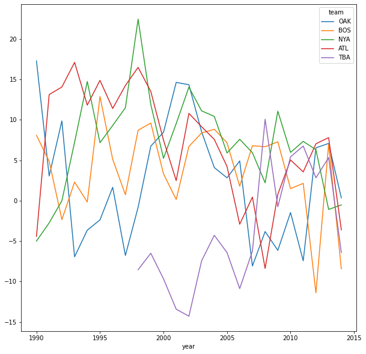

```python
teams = ['OAK', 'BOS', 'NYA', 'ATL', 'TBA']
sals['efficiency'] = sals['win_percentage'] - (50 + 2.5 * sals['std_payroll'])
#separate data by team instead of by year, and have efficiency vals as the values
p8_df = sals.pivot(index='year', columns='team', values='efficiency')
#isolate columns specified
p8_df = p8_df[teams]
p8_df.plot.line(figsize = (10,10))
```

**Question 4 (9 pts)** What can you learn from this plot compared to the set of plots you looked at in Question 2 and 3? How good was Oakland's efficiency during the Moneyball period?

> a. With the first graph, we know the distributions in regards to spending. In the second graph, we've learned that regardless of the team's spending habits, the vast majority of the wins hover between 40-60%, with a loose positive correlation. However with the understanding that correlation doesn't necessarily equate to causation, the plot in question 3 uses the win percentage and the salaries to further develop what the data in Q3 means. i.e. if team a spends 20% more in salary than team b and team a wins 70% of the time and team b wins 64% of the time, who gets the overall higher payoff? This could matter, if for instance, a team owner is looking at budget cuts and trying to find an optimal value that could minimize budgeting while maximizing the wins. While the plots in Q2 or Q3 cannot answer these questions, this one can.

> With the assumption that an efficiency value>=0 is considered "efficient spending" and an efficiency value < 0 to not be efficient spending, Oakland appears to be an less of an efficient spender compared to the other teams (with the exception of TBA

```python
for i in teams:
  print(i + "'s % efficiency:" + str(len((sals[sals.team == i])[sals.efficiency
                                                                >= 0])/len((sals[sals.team == i]))))
```

```
OAK's % efficiency:0.6
BOS's % efficiency:0.84
NYA's % efficiency:0.8
ATL's % efficiency:0.84
TBA's % efficiency:0.29411764705882354
```